# surface_recon

```python
import pandas as pd
from matplotlib import pyplot as plt
%matplotlib inline
import numpy as np
from scipy.interpolate import griddata
import matplotlib as mpl
from adsy.display import extended_styles
from IPython.display import Image
```

```python
extended_styles()
```

Toggle Input

```python
data = pd.read_csv("./LidarPointExport_subset.txt", thousands=',')
data = data.convert_objects(convert_numeric=True)
data = data[["Z_meters", "XcoordMeters", "YcoordMeters"]]
data.columns=["Z", "X", "Y"]
zmin =data.Z.min()
zmax = data.Z.max()
data= data.sort("Z")
```

First lets look at the image we are working with...

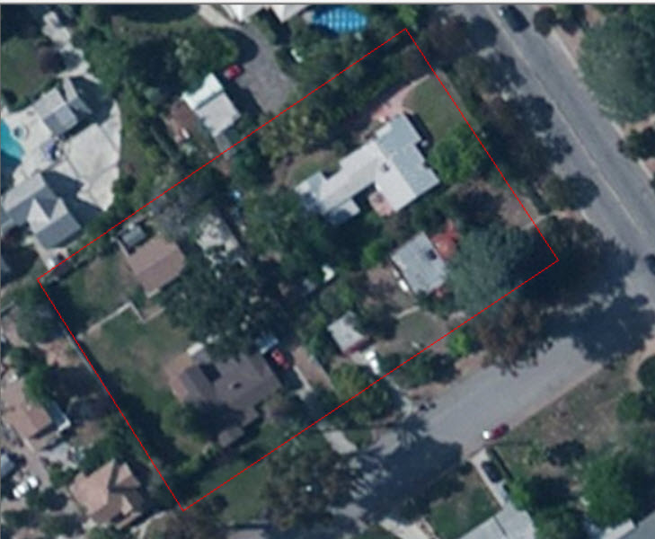

```python
Image("./LidarExport_SubsetArea.jpg")
```

Now let's look at the Lidar data. The points are color coded by elevation

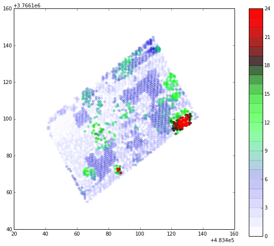

```python
colorlist = []
for c in np.arange(0,1,.01):
    colorlist.append((max(0,-16*c**2+32*c -15), max(0, -16*c**2+16*c -3), max(0, -4*c**2 +1), c))
#mycmap =  mpl.colors.ListedColormap(colorlist)
cmap = plt.cm.jet
cmap = cmap.from_list('Custom cmap', colorlist, cmap.N)
fig, ax = plt.subplots(1,1, figsize=(8,8))
for ix, row in data.iterrows():
    c = (row.Z - zmin)/(zmax-zmin)
    ax.scatter(row.X, row.Y, color=(max(0,-16*c**2+32*c -15), max(0, -16*c**2+16*c -3), max(0, -4*c**2 +1)),
               alpha=c)
ax2 = fig.add_axes([0.95, 0.1, 0.05, 0.8])
bounds = np.arange(0, zmax-zmin)
norm = mpl.colors.Normalize(vmin=0, vmax=25)
cb = mpl.colorbar.ColorbarBase(ax2, cmap=cmap, boundaries=bounds)


#fig.text(1.1, .5, "Elevation (meters)")
```

So if we want to fully automate this process, we have two tasks:

1. We need to figure out what is a roof and what is the ground
2. On the roof, we need to pick apart the planes.

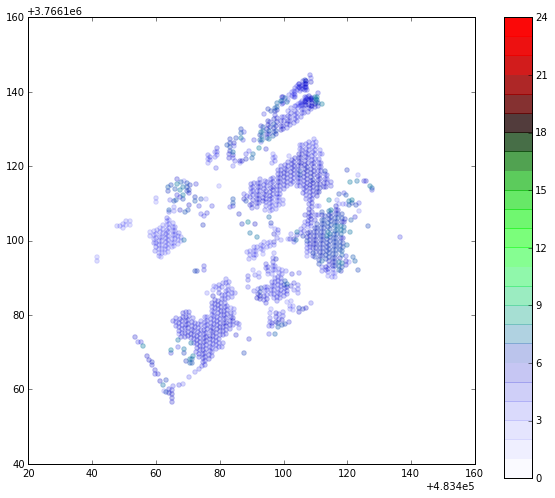

```python
colorlist = []
for c in np.arange(0,1,.01):
    colorlist.append((max(0,-16*c**2+32*c -15), max(0, -16*c**2+16*c -3), max(0, -4*c**2 +1), c))
#mycmap =  mpl.colors.ListedColormap(colorlist)
cmap = plt.cm.jet
cmap = cmap.from_list('Custom cmap', colorlist, cmap.N)
fig, ax = plt.subplots(1,1, figsize=(8,8))
for ix, row in data.iterrows():
    c = (row.Z - zmin)/(zmax-zmin)
    if c > 3/25. and c<8/25. :
        ax.scatter(row.X, row.Y, color=(max(0,-16*c**2+32*c -15), max(0, -16*c**2+16*c -3), max(0, -4*c**2 +1)),
               alpha=c)
ax2 = fig.add_axes([0.95, 0.1, 0.05, 0.8])
bounds = np.arange(0, zmax-zmin)
norm = mpl.colors.Normalize(vmin=0, vmax=25)
cb = mpl.colorbar.ColorbarBase(ax2, cmap=cmap, boundaries=bounds)
#for p in ptlist:
#    arr = np.asarray(p)
#    ax.scatter(arr[:,0], arr[:,1], color =(np.random.random(),np.random.random(),np.random.random(),))
```

From this we get the outline of the four houses, a garage and some medium height trees. However, we have significantly reduced the data we need to process just by setting height restrictions.

# Initial Algorithm

This is loosely based on:

Jann Poppinga, Narunas Vaskevicius, Andreas Birk, and Kaustubh Pathak. *"Fast Plane Detection and Polygonalization in noisy 3D Range Images"*

The gist is:

```python
# Get all rooftop points
high_points = []
for ix, row in data.iterrows():
    c = (row.Z - zmin)/(zmax-zmin)
    if c > 3/25. and c<8/25. :
        high_points.append((row.X, row.Y, row.Z))
```

```python
# Get distance to all other points
def get_nearest(high_points):
    pt_label=0
    nearest_sort = {}
    for p in high_points:
        pdists = []
        for op in high_points:
            distance = ((p[0]- op[0])**2 + (p[1]- op[1])**2 + (p[2]- op[2])**2)**.5
            pdists.append(distance)
        ordered = np.argsort(pdists)
        nearest_sort[pt_label]=ordered[1:]
        pt_label +=1
    return nearest_sort

def get_plane_equation(a,b,c):
    v1 = np.asarray(a) - np.asarray(c)
    v2 = np.asarray(b) - np.asarray(c)
    coeffs = list(np.cross(v1 ,v2))
    const = a[0]*coeffs[0] +a[1]*coeffs[1] +a[2]*coeffs[2]
    coeffs.append(const)
    return coeffs
```

```python
def get_surfaces(points, maxdistance=10, delta=.1, minpts=30, samplim=20000):
    """
    This is not right because we need to look for nearest not remaining
    pts
    """
    nearest = get_nearest(points)
    unknown = []
    surfaces = []
    numsamps = 0
    pt_ix_to_sample = list(np.arange(0, len(points)))
    pt_to_ix_dict = {str(points[x]): x for x in range(len(points))}
    plane_list = []
    while len(pt_ix_to_sample) > 0 and numsamps<samplim:
        pix = np.random.choice(pt_ix_to_sample)
        p = points[pix]
        #nearest_left = [x for x in nearest[pix] if x in pt_ix_to_sample]
        nearest_left = [x for x in nearest[pix]]
        closeix1 = np.random.choice(nearest_left[1:3])
        closeix2 = np.random.choice(nearest_left[3:6])
        close1 = points[closeix1]
        close2 = points[closeix2]
        plane = get_plane_equation(points[pix], close1, close2)
        insurface_ix = [closeix1, closeix2]
        #plane = get_plane_equation(points[pix], points[nearest_left[0]], points[nearest_left[1]])
        #insurface_ix = [nearest_left[0], nearest_left[1]]
        distance_away = 0
        next_pt_ix = 2
        while distance_away < maxdistance:
            op  = points[nearest_left[next_pt_ix]]
            distance_away =  ((p[0]- op[0])**2 + (p[1]- op[1])**2 + (p[2]- op[2])**2)**.5
            #squareerror = (sum(plane[i] * op[i] for i in range(3)) - plane[3])**2
            ## You are an idiot and need to review calculus.
            #print p, op, plane, '\n'
            squareerror =  (sum([plane[i] * op[i] for i in range(3)]) - plane[3]) / (
                plane[0]**2 + plane[1]**2 + plane[2]**2)**.5
            #print squareerror
            if abs(squareerror) < delta:
                insurface_ix.append(nearest[pix][next_pt_ix])
            next_pt_ix += 1
        if len(insurface_ix) > minpts:
            pt_ix_to_sample = [x for x in pt_ix_to_sample if x not in insurface_ix]
            surfaces.append(insurface_ix)
            plane_list.append(plane)
        numsamps +=1
    return surfaces, plane_list


s, planes=get_surfaces(high_points)
```

```python
def get_points(ixlists, points):
    allpoints = []
    for l in ixlists:
        innerlist = []
        for j in l:
            innerlist.append(points[j])
        allpoints.append(innerlist)
    return allpoints
```

```python
from ipywidgets import StaticInteract, RangeWidget, RadioWidget
```

### Results

All points of the same color are assumed to lie on a single plane

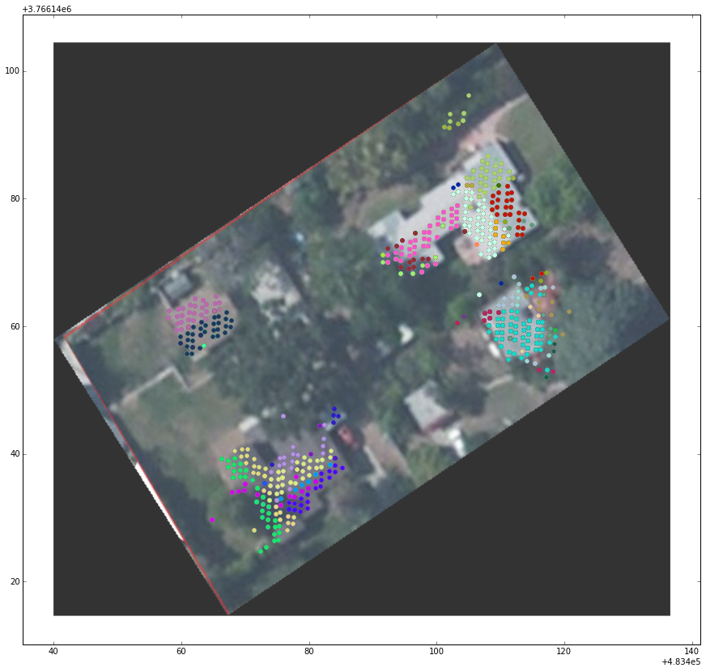

```python
def splot(View):
    fig, ax = plt.subplots(figsize=(15,15))
    if View =="Overlay":
        ptlist = get_points(s, high_points)
        datafile = cbook.get_sample_data('/home/justin/Documents/isea/LidarExport_SubsetAreacropped.jpg')
        img = imread(datafile)
        img = ndimage.rotate(img, 33)
        south = min(data.Y)
        north = max(data.Y)
        east = min(data.X)
        west = max(data.X)
        ax.imshow(img, zorder=0, alpha=.8, extent=[east, west, south,north])
        alreadyincluded=[]
        lenofincluded = []
        for p in ptlist:
            arr = np.asarray(p)
            ax.scatter(arr[:,0], arr[:,1], color =(np.random.random(),np.random.random(),np.random.random(),))
        return fig
    elif View =="Surfaces":
        ptlist = get_points(s, high_points)
        datafile = cbook.get_sample_data('/home/justin/Documents/isea/LidarExport_SubsetAreacropped.jpg')
        img = imread(datafile)
        img = ndimage.rotate(img, 33)
        south = min(data.Y)
        north = max(data.Y)
        east = min(data.X)
        west = max(data.X)
        #ax.imshow(img, zorder=0, alpha=.8, extent=[east, west, south,north])
        for p in ptlist:
            arr = np.asarray(p)
            ax.scatter(arr[:,0], arr[:,1], color =(np.random.random(),np.random.random(),np.random.random(),))
        return fig
    elif View=="Image":
        ptlist = get_points(s, high_points)
        datafile = cbook.get_sample_data('/home/justin/Documents/isea/LidarExport_SubsetAreacropped.jpg')
        img = imread(datafile)
        img = ndimage.rotate(img, 33)
        south = min(data.Y)
        north = max(data.Y)
        east = min(data.X)
        west = max(data.X)
        ax.imshow(img, zorder=0, alpha=.8, extent=[east, west, south,north])
        return fig

from IPython.html.widgets import interact, FloatSlider, RadioButtons, interact_manual
slider1=RadioButtons(options=["Image","Overlay","Surfaces"])
print interact(splot, View=slider1)
```

We see that with this algorithm, we can get a rough improint of where the surfaces are. The next steps would be:

1. Improve the algorithm (speed and accuracy).
2. Improve the display/results
3. Find the optimal panel allocation.

Right off the bat, I can tell you it will be almost impossible to account for things like chimneys, skylights or all small obstructions on the roofs. However, maybe this is not necessary?

# Scratch Work Ignore

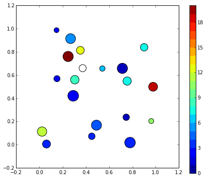

```python
# setup the plot
fig, ax = plt.subplots(1,1, figsize=(6,6))

# define the data
x = np.random.rand(20)
y = np.random.rand(20)
tag = np.random.randint(0,20,20)
#tag[10:12] = 0 # make sure there are some 0 values to showup as grey

# define the colormap
cmap = plt.cm.jet
# extract all colors from the .jet map
cmaplist = [cmap(i) for i in range(cmap.N)]
# force the first color entry to be grey
cmaplist[0] = (1,1,1)
cmaplist[1] = (1,1,1)
cmaplist[2] = (1,1,1)
cmaplist[3] = (1,1,1)
# create the new map
cmap = cmap.from_list('Custom cmap', cmaplist, cmap.N)

# define the bins and normalize

bounds = np.linspace(0,20,21)
#norm = mpl.colors.BoundaryNorm(bounds, cmap.N)

# make the scatter
scat = ax.scatter(x,y,c=tag,s=np.random.randint(100,500,20), cmap=cmap)

# create a second axes for the colorbar
ax2 = fig.add_axes([0.95, 0.1, 0.03, 0.8])
cb = mpl.colorbar.ColorbarBase(ax2, cmap=cmap,  boundaries=bounds, format='%1i')

#ax.set_title('Well defined discrete colors')
#ax2.set_ylabel('Very custom cbar [-]', size=12)
```